# Using `ivis` and Seurat for Analysis of Single Cell Datasets

This example will demonstrate how `ivis` can be used to visualise single cell experiments. Data import, preprocessing and normalisation are handled by the Seurat library. The data that will be used in this example consists of 3,000 PBMCs from a healthy donor and is freely available from 10x Genomics. The data can be download manually in the following way.

```bash
mkdir data
wget http://cf.10xgenomics.com/samples/cell-exp/1.1.0/pbmc3k/pbmc3k_filtered_gene_bc_matrices.tar.gz -O data/pbmc3k_filtered_gene_bc_matrices.tar.gz
cd data; tar -xzf pbmc3k_filtered_gene_bc_matrices.tar.gz
```

Alternatively, the [`TENxPBMCData`](https://bioconductor.org/packages/release/data/experiment/html/TENxPBMCData.html) Bioconductor package provides tools to download and cache locally each of the 10x Genomics datasets.

```r
library(TENxPBMCData)
pbmc3k.sce <- TENxPBMCData(dataset = "pbmc3k")
pbmc3k.sce
```

```
#> class: SingleCellExperiment
#> dim: 32738 2700
#> metadata(0):
#> assays(1): counts
#> rownames(32738): ENSG00000243485 ENSG00000237613 ...
#>   ENSG00000215616 ENSG00000215611
#> rowData names(3): ENSEMBL_ID Symbol_TENx Symbol
#> colnames: NULL
#> colData names(11): Sample Barcode ... Individual Date_published
#> reducedDimNames(0):
#> spikeNames(0):
```

The data is obtained in the `SingleCellExperiment` class and can be converted to a `Seurat` object as follows.

```r
library(Seurat)
colnames(pbmc3k.sce) <- paste0("Cell", seq_len(ncol(pbmc3k.sce)))
pbmc <- CreateSeuratObject(counts = assay(pbmc3k.sce, "counts"), project = "pbmc3k",
                           min.cells = 3, min.features = 200)
pbmc
```

```
#> An object of class Seurat
#> 13714 features across 2700 samples within 1 assay
#> Active assay: RNA (13714 features)
```

## Data Preprocessing

The steps below reflect a standard preprocessing workflow, as described in the [Seurat vignette](https://satijalab.org/seurat/v3.0/pbmc3k_tutorial.html).

```r
pbmc[["percent.mt"]] <- PercentageFeatureSet(pbmc, pattern = "^MT-")
pbmc <- subset(pbmc, subset = nFeature_RNA > 200 & nFeature_RNA < 2500 & percent.mt < 5)
bmc <- NormalizeData(pbmc, normalization.method = "LogNormalize", scale.factor = 10000)

pbmc <- FindVariableFeatures(pbmc, selection.method = "vst", nfeatures = 2000)
all.genes <- rownames(pbmc)
pbmc <- ScaleData(pbmc, features = all.genes)
```

Due to a large number of features (>13,000), it is recommended to initially perform linear dimensionality reduction using Principal Component Analysis (PCA) to reduce some noise that’s present in the data.

```r
pbmc <- RunPCA(pbmc, features = VariableFeatures(object = pbmc))
```

[output not shown]

## Cluster the Cells

```r
pbmc <- FindNeighbors(pbmc, dims = 1:10)
pbmc <- FindClusters(pbmc, resolution = 0.5)
```

```
#> Modularity Optimizer version 1.3.0 by Ludo Waltman and Nees Jan van Eck
#>
#> Number of nodes: 2695
#> Number of edges: 92019
#>
#> Running Louvain algorithm...
#> Maximum modularity in 10 random starts: 0.8841
#> Number of communities: 11
#> Elapsed time: 0 seconds
```

## Non-linear Dimensionality Reduction using `ivis`

We are now ready to apply `ivis` to the PBMC dataset.

```r
library(ivis)

model = ivis(embedding_dims=2, k=15, model='maaten',
             n_epochs_without_progress=20)

X = pbmc@reductions$pca@cell.embeddings

embeddings = model$fit_transform(X)
colnames(embeddings) <- paste0("ivis_", 1:2)
rownames(embeddings) <- rownames(X)

pbmc[["ivis"]] <- CreateDimReducObject(embeddings = embeddings,
                                       key = "ivis_", assay = DefaultAssay(pbmc))
```

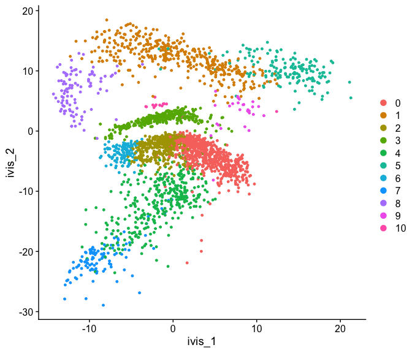

```r
DimPlot(pbmc, reduction="ivis", pt.size = 1)
```

`ivis` effectively captured distinct cellular populations in this small dataset. Note that `ivis` is an “honest” algorithm and distances between observations are meaningful. Our benchmarks show that `ivis` is ~10% better at preserving local and global distances in low-dimensional space than comparable state-of-the-art algorithms. Additionally, `ivis` is robust against noise and outliers, ulike t-SNE, which tends to group random noise into well-defined clusters that can be potentially misleading.

Keep in mind that this is a very small experiment (<3000 observations) and there are plenty of fast and accurate algorithm designed for these kinds of datasets e.g. UMAP. However, if you have >250,000 cells, `ivis` considerably outperforms state-of-the-art both in speed and accuracy of embeddings. See our [timings benchmarks](https://bering-ivis.readthedocs.io/en/latest/timings_benchmarks.html#timings-benchmarks) for more information on this.

Finally, to find out more about `ivis` [hyperparameters](https://bering-ivis.readthedocs.io/en/latest/hyperparameters.html) and [API](https://bering-ivis.readthedocs.io/en/latest/api.html) checkout the official documentation.